# Types of Data Science Questions

## Types of Data Science Questions

**In approximate order of difficulty** * Descriptive * Exploratory * Inferential * Predictive * Causal * Mechanistic

## About descriptive analyses

**Goal**: Describe a set of data

- The first kind of data analysis performed
- Commonly applied to census data
- The description and interpretation are different steps
- Descriptions can usually not be generalized without additional statistical modeling

## Descriptive analysis

[figure not shown]

http://www.census.gov/2010census/

## Descriptive analysis

[figure not shown]

http://books.google.com/ngrams

## About exploratory analysis

**Goal**: Find relationships you didn't know about

- Exploratory models are good for discovering new connections
- They are also useful for defining future studies
- Exploratory analyses are usually not the final say
- Exploratory analyses alone should not be used for generalizing/predicting
- [Correlation does not imply causation](http://en.wikipedia.org/wiki/Correlation_does_not_imply_causation)

## Exploratory analysis

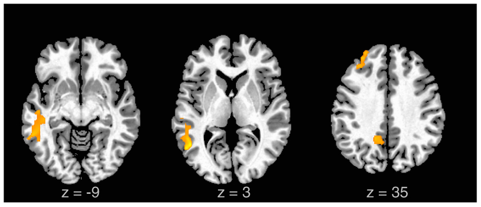

[Liu et al. (2012) Scientific Reports](http://www.nature.com/srep/2012/121115/srep00834/full/srep00834.html)

## Exploratory analysis

[figure not shown]

http://www.sdss.org/

## About inferential analysis

**Goal**: Use a relatively small sample of data to say something about a bigger population

- Inference is commonly the goal of statistical models
- Inference involves estimating both the quantity you care about and your uncertainty about your estimate
- Inference depends heavily on both the population and the sampling scheme

## Inferential analysis

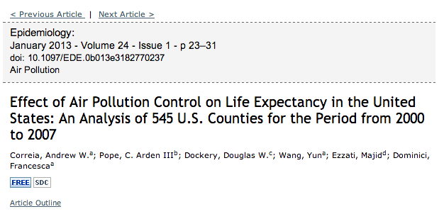

[Correia et al. (2013) Epidemiology](http://journals.lww.com/epidem/Fulltext/2013/01000/Effect_of_Air_Pollution_Control_on_Life_Expectancy.4.aspx)

## About predictive analysis

**Goal**: To use the data on some objects to predict values for another object

- If \(X\) predicts \(Y\) it does not mean that \(X\) causes \(Y\)
- Accurate prediction depends heavily on measuring the right variables
- Although there are better and worse prediction models, more data and a simple model [works really well](http://www.youtube.com/watch?v=yvDCzhbjYWs)
- Prediction is very hard, especially about the future [references](http://www.larry.denenberg.com/predictions.html)

## Predictive analysis

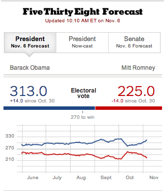

http://fivethirtyeight.blogs.nytimes.com/

## Predictive analysis

[figure not shown]

http://www.forbes.com/sites/kashmirhill/2012/02/16/how-target-figured-out-a-teen-girl-was-pregnant-before-her-father-did/

## About causal analysis

**Goal**: To find out what happens to one variable when you make another variable change.

- Usually randomized studies are required to identify causation
- There are approaches to inferring causation in non-randomized studies, but they are complicated and sensitive to assumptions
- Causal relationships are usually identified as average effects, but may not apply to every individual
- Causal models are usually the "gold standard" for data analysis

## Causal analysis

[figure not shown]

[van Nood et al. (2013) NEJM](http://www.nejm.org/doi/full/10.1056/NEJMoa1205037?query=featured_home)

## About mechanistic analysis

**Goal**: Understand the exact changes in variables that lead to changes in other variables for individual objects.

- Incredibly hard to infer, except in simple situations
- Usually modeled by a deterministic set of equations (physical/engineering science)
- Generally the random component of the data is measurement error
- If the equations are known but the parameters are not, they may be inferred with data analysis

## Mechanistic analysis

[figure not shown]

http://www.fhwa.dot.gov/resourcecenter/teams/pavement/pave_3pdg.pdf